# Title of Blog Post Deliverable

## 2.5 Question 5

Generate histogram of median sampling distribution and use “dorder” to get the theoretical PDF

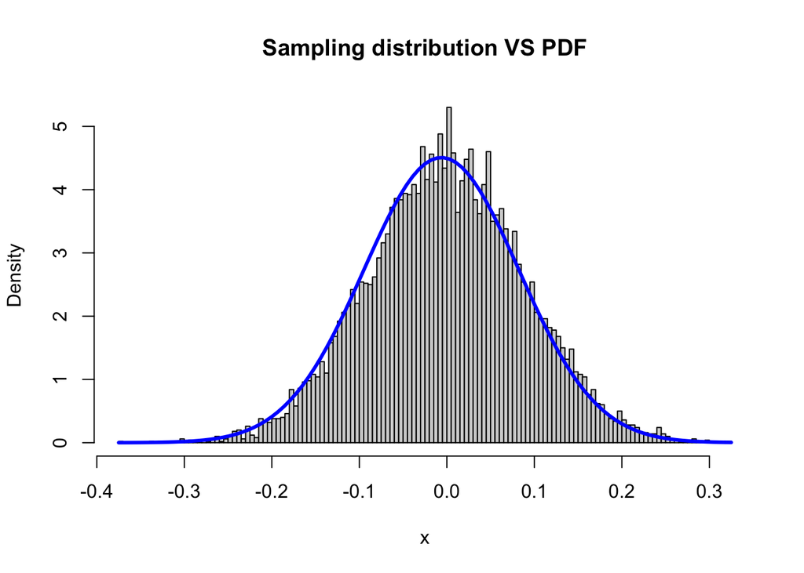

```r
# get 10000 sample
median_norm <- rep(NA,10000)
for (i in seq_along(median_norm))
{
  # calculate median for each sample
  median_norm[i] = rnorm(200,mean = 0, sd=1) %>% median
}
# plot 10000 sample
hist(
  median_norm,
  breaks = 100,
  main = "Sampling distribution VS PDF",
  xlab = "x",
  freq = FALSE
)
# use "dorder" to get the plot of PDF
curve(
  dorder(x),
  lwd = 3,
  col = "blue",
  add=TRUE
)
```

Based on the graphic, the shape of histogram is basically consistent with the shape of the generated density function，which proves that the density function is likely to be accurate.

## 2.6 Question 6

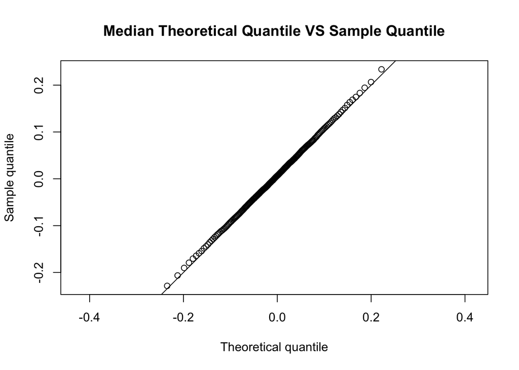

```r
# get 10000 sample
median_norm_2 <- rep(NA,10000)
for (i in seq_along(median_norm_2)){
  # calculate median for each sample
  median_norm_2[i]  <- rnorm(200,mean=0, sd=1) %>% median
}
# sort the list
median_norm_2 <- median_norm_2 %>% sort()
# want to explore 199 quantiles except 0 and 1 quantile
y <- rep(NA, 199)
for (i in seq_along(y))
{
  y[i] = median_norm_2[10000*i/200]
}
# compatible with x
x = qorder((1:199)/200)

plot(x,y
     ,asp=1
     ,main = "Median Theoretical Quantile VS Sample Quantile"
     ,xlab = "Theoretical quantile"
     ,ylab = "Sample quantile"
     )
abline(0,1)
```

Based on the graphic, the plotted points almost fall along the line y=x. Thus the simulated median agree with the theoretical sampling distribution, which proves that the quantile function is likely to be accurate.

## 2.7 Question 7

The updated function is the version of corresponding function from Question 1 using k to replace 100.

```r
# n=200,k=k
dorder_anyOrder <- function(x,k){
  k*
    choose(200,k)*
    (pnorm(x, mean=0, sd =1))^(k-1)*
    (1-pnorm(x, mean=0, sd =1))^(200-k)*
    dnorm(x, mean=0, sd =1)
}

# n=200,k=k
porder_anyOrder <- function(x,k){
  pbinom(k-1, 200, pnorm(x, mean=0, sd=1), lower.tail = FALSE)
}

# n = 200,k=k
qorder_anyOrder <- function(x,k){
  lt <- data.frame(x=seq(-4,15,by=0.01)) %>%
     mutate(p = porder_anyOrder(x,k))
  qf <-approxfun(lt$p,lt$x, ties ="ordered")
  qf(x)
}
```

## 2.8 Question 8

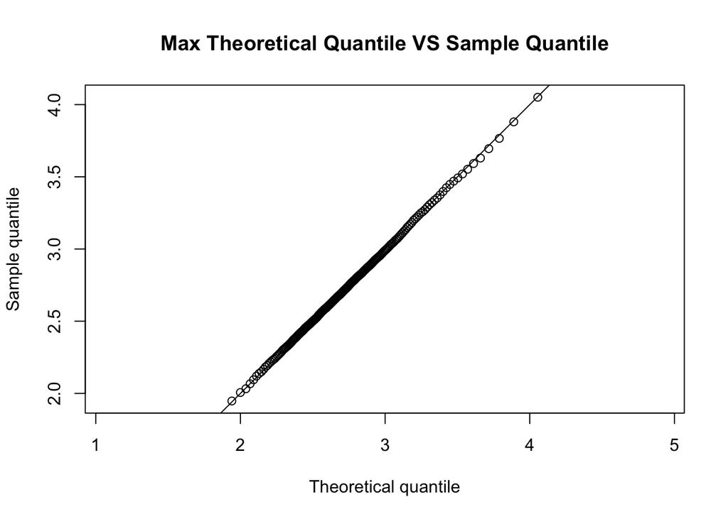

```r
# get 10000 samples
max_norm <- rep(NA,10000)
for (i in seq_along(max_norm)){
  # calculate the max for each sample
  max_norm[i] = rnorm(200,mean=0, sd=1) %>% max
}
# sort the list
max_norm <- max_norm %>% sort()

# want to explore 199 quantiles
y <- rep(NA,199)
for (i in seq_along(y)){
  y[i] = max_norm[10000*i/200]
}
# use function "qorder_anyOrder" with k = 200(max)
x<-qorder_anyOrder((1:199)/200,200)
plot(x,y, asp = 1,
     xlab = "Theoretical quantile",
     ylab = "Sample quantile",
     main =  "Max Theoretical Quantile VS Sample Quantile")
abline(0,1)
```

Based on the above graphic, the plotted points almost fall along the line y=x. Thus the simulated max agree with the theoretical sampling distribution, which proves that the updated quantile function is likely to be accurate.

## 2.9 Question 9

The new function needs two more variables “dist” and “…”. “dist” contains the name information of the distribution and “…” contains the parameter information of the distribution

```r
# combine two strings
`%|%` <- function(a,b) paste0(a,b)

dorder_anyOrderDistri <- function(x,k,dist,...){
  # CDF
  F <- eval(parse(text ="p" %|% dist))
  # PDF
  f <- eval(parse(text ="d" %|% dist))
  k*
    choose(200,k)*
    (F(x, ...))^(k-1)*
    (1-F(x, ...))^(200-k)*
    f(x, ...)
}

porder_anyOrderDistri <- function(x,k,dist,...){
  # CDF
  F <- eval(parse(text ="p" %|% dist))
  pbinom(k-1, 200, F(x, ...), lower.tail = FALSE)
}

qorder_anyOrderDistri <- function(x,k,dist,...){
  lt <- data.frame(x=seq(-4,15,by=0.01)) %>%
     mutate(p = porder_anyOrderDistri(x,k,dist,...))
  qf <-approxfun(lt$p,lt$x)
  qf(x)
}
```

## 2.10 Question 10

Based on the question introduction, n=200,k=1(min), and this is about the standard normal distribution.

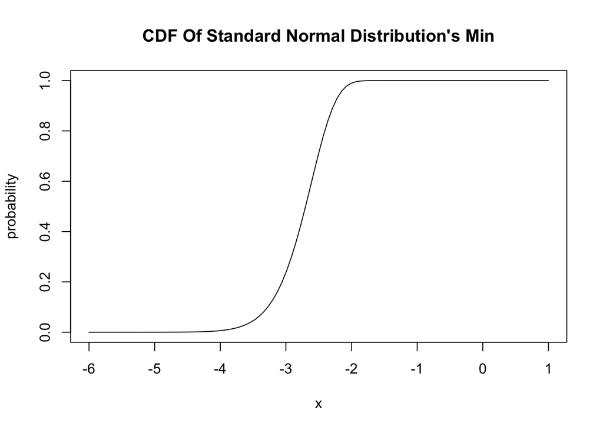

```r
#Use the newly modified functions to plot the probability and density functions for the sample min (N=200)
# CDF
curve(
  porder_anyOrderDistri(x,1,"norm",mean=0,sd=1),
  ylab = "probability",
  xlim = c(-6,1),
  main = "CDF Of Standard Normal Distribution's Min"
)
```

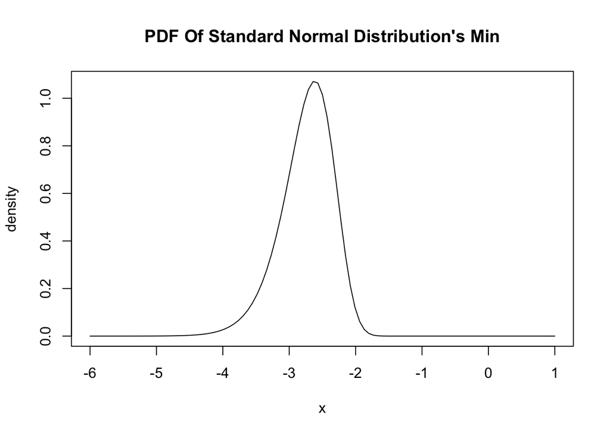

```r
# PDF
curve(
  dorder_anyOrderDistri(x,1,"norm", mean=0,sd=1),
  ylab = "density",
  xlim = c(-6,1),
  main ="PDF Of Standard Normal Distribution's Min"
)
```

The first graphic is the CDF of standard normal distribution’ min and the second graphic is the PDF of standard normal distribution’ min